# Probability and Linear Algebra Review

Eric Bridgeford

October 23, 2017

# Random Variable

$$\begin{align*}
X: \Omega \rightarrow E
\end{align*}$$

- variable whose outcomes occur as a result of random phenomenon
  - Example: flipping a coin can be modeled with a bernoulli random variable (more on that in a second)
- $\Omega$ represents the domain that the variable can occupy: set of possible outcomes in our probability space
- $E$ represents the range that the variable can occupy: usually probabilities
- parametric RV: distribution of the random variable can be PARAMETRIZED by a fixed set $\theta$
  - written $X \sim dist(\theta)$ for distribution $dist$
  - $p(x \in X | \theta)$, that is, the distribution is a function of $x$ and the parameters $\theta$
  - Example: normal distribution: $X \sim \mathcal{N}(\mu, \sigma^2)$

## Moments

- a statistic that gives information about the “shape” of a set of points
- first moment: mean (what is the center of the points?) $\mathbb{E}X$
- second moment: rotational inertia (how clustered about the mean are the points?) $\mathbb{E}X^2$
- definition:
  - discrete: $\mathbb{E}X^n = \sum_{i=1}^k p_X\left(x_i\right)x_i^n$ where $x_i$s are our possible outcomes
  - continuous $\mathbb{E}X^n = \int_{i=-\infty}^\infty p_X(x)x^n dx$
- these will be vital for our understanding of analytical understanding of parameter estimates in later steps
  - analytical: we have descriptions of characteristics of the data itself $a-priori$ (know them ahead of time)

## Likelihood

- gives understanding of the fit of data to the parameters of a statistical model
  $$\begin{align*}
  L(x | \theta) = \prod_{i=1}^n p(x_i | \theta)
  \end{align*}$$
- where $p(x_i)$ is the probability of a given item $x_i$ given our parameters $\theta$
- Interesting observation: taking the log of the likelihood will give something that will preserve the form of the likelihood
  - log function is always increasing: “monotonicity”
  - if $A > B$, then $log(A) > log(B)$ due to $log$ being monotonic
  - if we optimize something over $log(f(\cdot))$, we have also optimized for $f(\cdot)$
  - idea: if $x'$ is the best solution of $f(x)$, then $log(f(x'))$ will still be the best solution for $log(f(x))$
- Gives rise to the log-likelihood, which has a much simpler form:

$$\begin{align*}
log\left(L(x | \theta)\right) = \sum_{i=1}^n log\left(p(x_i | \theta)\right)
\end{align*}$$

## Estimation

- estimator: rule for calculating an estimate of some quantity on empirical (observed) data
- motivation: we will virtually never have our parameters $\theta$ $a-priori$
  - but, we will have observations of the data, which should mean we can obtain the parameters given enough observations

### Maximum Likelihood Estimation (MLE)

- goal: $\hat{\theta} = \textrm{argmax}_{\theta} L(x | \theta)$ where $x = \{x_i\}_{i=1}^n$ are our $n$ data observations
- use monotonicity: $\hat{\theta} = \textrm{argmax}_{\theta} log\left(L(x | \theta)\right)$
- use calculus: $\hat{\theta}_j := \frac{\delta\, log\left(L(x | \theta)\right)}{\delta \theta_j} = 0$
- use this when you have empirical data and want to apply a given model to it

## Discrete RV

- $|\Omega| = C$; that is, the space of possible values is finite
  - $|\{\cdot\}|$ means the cardinality of the set: the number of elements the set $\{\cdot\}$ contains

### Bernoulli RV

$$\begin{align*}
X &\sim Bern(p) \\
X&: \Omega=\{0, 1\} \rightarrow E=\mathbb{R} \\
p(x \in \Omega) &=
\begin{cases}
p & x = 1 \\
(1-p) & x=0
\end{cases} \\
p(x \in \Omega) &= p^x(1-p)^{1 - x}
\end{align*}$$

- our probability space has 2 elements here: x can take either $0$ or $1$, 2 DISCRETE possibilities
- Definition of Bernoulli RV tells us the probability mass function (pmf) $p(x)$ for $x \in \Omega$
- $\hat{p} = \hat{p}(x = 1) = \mathbb{E}X = 0 p(x = 0) + 1 p(x = 1)$
  - $\hat{\cdot}$ means the estimator of $\cdot$:
  - note that $x_0$ = 0: so $\hat{p} = p(x = 1)$
- Likelihood model
  $$\begin{align*}
  L(x | p) &= \prod_{i=1}^n p(x_i | p) \\
  &= \prod_{i=1}^n p^{x_i}(1-p)^{1-x_i} \\
  &= p^{\sum_{i=1}^n x_i} (1-p)^{n - \sum_{i=1}^n x_i} \\
  log(L(x | p)) &= \left(\sum_{i=1}^n x_i\right) log(p) + \left(n - \sum_{i=1}^n(x_i)\right) log(1-p)
  \end{align*}$$
- use MLE as above for each of our parameters $\theta = \{p\}$
  $$\begin{align*}
  \frac{\delta log(L(x | p))}{\delta p} &= \frac{\left(\sum_{i=1}^n x_i\right)}{p} - \frac{\left(n - \sum_{i=1}^n(x_i)\right)}{1-p} = 0 \\
  \sum_{i=1}^n x_i - p\sum_{i=1}^n x_i &= np - p\sum_{i=1}^n x_i \\
  \hat{p} &= \frac{\sum_{i=1}^n x_i}{n}
  \end{align*}$$

In the below code-snippet, we check for convergence: does the probability of obtaining outcome $1$ actually approach $p$ as our number of samples increases?

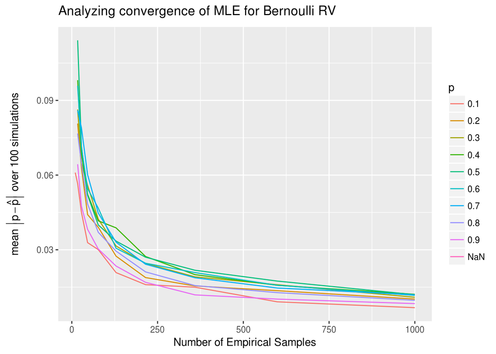

```r
require(ggplot2)
library(latex2exp)

sim.bern <- function(p, n=1) {
  # get a uniform RV from 0 to 1 (every value has the same probability)
  # this means that numbers between 0 and p occur with probability p, and numbers from p to 1 occur with probability (1-p)
  # which is exactly the definition of our bernoulli RV
  # if runif(1) which is 1 sample from uniform RV on range 0 to 1 is less than p, return 1, else 0
  return(replicate(n, ifelse(runif(1) <= p, 1, 0)))
}


maxn = 1000
# define a range of ns from 10 to 10^3 in logarithmic spacing
ns = round(10^seq(1, log10(maxn), length=10))

ps = seq(.1, .9, length.out=9)
# initialize where the result will be stored
empty_ar = array(NaN, dim=c(length(ns)*length(ps)))
results <- data.frame(n = empty_ar, er = empty_ar, p=empty_ar)
nsim = 100  # number of simulations per number of empirical samples

for (i in 1:length(ns)) {
  for (j in 1:length(ps)) {
    # ns[i] is the number of empirical samples on a given iteration
    # replicate(nsim, ...) repeats ... nsim times
    # sim.bern(ptru, n=ns[i]) simulates ns[i] bernoulli RVs
    # sum(sim.bern(ptru, n=ns[i]))/ns[i] is our estimator of p defined above
    dat <-  replicate(nsim, sim.bern(ps[j],  n=ns[i]))
    er <- mean(abs(ps[j] - apply(dat, 2, sum)/ns[i]))

    results[i + (j-1)*length(ps),] <- data.frame(n = ns[i], er=er, p=ps[j])
  }
}

results$p = factor(results$p)
ggplot(data=results, aes(x=n, y=er, group=p, color=p)) +
  geom_line() +
  ggtitle(TeX('Analyzing convergence of MLE for Bernoulli RV')) +
  xlab('Number of Empirical Samples') +
  ylab(TeX('mean $\\left|p - \\hat{p}\\right|$ over 100 simulations'))
```